# R Notebook

1. **Tema**

   Análisis del servicio de alojamiento de Airbnb en nueve ciudades en Europa del 2023.
2. **Objetivo general**

   Analizar del servicio de alojamiento de Airbnb en nueve ciudades en Europa del 2023.
3. **Objetivos**
- Analizar las ciudades con mejor ranking de experiencia de Airbnb en Europa del 2023.
- Describir las características de los alojamientos más caros y más económicos en ciudades de Europa del 2023.
- Analizar la atracción de un Airbnb y su relación con su ubicación en ciudades de Europa del 2023.
3. **Instrumento de recolección**
- Acceso a data de fuente secundaria ( 41 mil observaciones: Datos sobre los AIRBNB de 9 ciudades famosas de Europa, Amsterdam, Athens, Barcelona, Berlin, Budapest, Lisbon, Paris, Rome and Vienna. )

  https://www.kaggle.com/datasets/dipeshkhemani/airbnb-cleaned-europe-dataset?group=bookmarked

  https://drive.google.com/file/d/1I1u893jIu2HbdGp-ljNbc6_ANqmrJ2Xq/view?usp=share_link
- Clasificación de variables

  | N° | Variable | Tipo |
  | --- | --- | --- |
  | 1 | City | (Categórica nominal) |
  | 2 | Cuándo lo reservan | (Categórica nominal) |
  | 3 | Room Type | (Categórica nominal) |
  | 4 | Shared Room | (Categórica nominal) |
  | 5 | Private Room | (Categórica nominal) |
  | 6 | Superhost | (Categórica nominal) |
  | 7 | Multiple Rooms | (Categórica nominal) |
  | 8 | Cleanliness Rating | (Categórica ordinal) |
  | 9 | Guest Satisfaction | (Categórica ordinal) |
  | 10 | Business (ofertas) | (Categórica nominal) |
  | 11 | Person Capacity | (Numérica discreta) |
  | 12 | Price | (Numérica continua) |
  | 13 | Bedrooms | (Numérica discreta) |
  | 14 | City Center (km) | (Numérica continua) |
  | 15 | Metro Distance (km) | (Numérica continua) |
  | 16 | Normalised attraction Index | (Numérica continua) |
  | 17 | Normalised restaurant index | (Numérica continua) |

```r
library(readr)
library(dplyr)
D <- read_csv("Aemf1.csv") #EL ARCHIVO Aemf1 y datos.AIRBNB es lo mismo.
```

- Eliminamos la columna 18 y 16, ya que de esas variables usamos sólo sus valores normalizados.

```r
View(D)

D$`Attraction Index` <- NULL
D$`Restraunt Index` <- NULL
```

- Re asignación de nombres :

```r
names(D)
```

```
##  [1] "City"                        "Price"
##  [3] "Day"                         "Room Type"
##  [5] "Shared Room"                 "Private Room"
##  [7] "Person Capacity"             "Superhost"
##  [9] "Multiple Rooms"              "Business"
## [11] "Cleanliness Rating"          "Guest Satisfaction"
## [13] "Bedrooms"                    "City Center (km)"
## [15] "Metro Distance (km)"         "Normalised Attraction Index"
## [17] "Normalised Restraunt Index"
```

```r
D %>% rename( Tipo = `Room Type` , Capacidad = `Person Capacity`, Oferta = Business, Habitaciones = Bedrooms, Ind.Atraccion = `Normalised Attraction Index`, Precio = Price, Share_Room = `Shared Room`, Limpieza = `Cleanliness Rating`, Ind.Restaurantes = `Normalised Restraunt Index`, Satisfaccion = `Guest Satisfaction`, Ciudad = City, Private_Room = `Private Room`, Distance_Center = `City Center (km)`, Distance_Metro = `Metro Distance (km)`) -> D2
```

```r
names(D2)
```

```
##  [1] "Ciudad"           "Precio"           "Day"              "Tipo"
##  [5] "Share_Room"       "Private_Room"     "Capacidad"        "Superhost"
##  [9] "Multiple Rooms"   "Oferta"           "Limpieza"         "Satisfaccion"
## [13] "Habitaciones"     "Distance_Center"  "Distance_Metro"   "Ind.Atraccion"
## [17] "Ind.Restaurantes"
```

- Búsqueda de NA’s y comprobación de casos completos

```r
Total_de_NAs <- sum(is.na(D))
print(paste("El total de NAs es :", Total_de_NAs))
```

```
## [1] "El total de NAs es : 0"
```

```r
Observaciones_completas <- sum(complete.cases(D2))
print(paste("Observaciones completas es : ",Observaciones_completas ))
```

```
## [1] "Observaciones completas es :  41714"
```

```r
Observaciones_incompletas <- sum(!complete.cases(D2))
print(paste("Observaciones incompletas es : ", Observaciones_incompletas))
```

```
## [1] "Observaciones incompletas es :  0"
```

### Limpieza de Datos

#### Verificar Variables booleanas

El primer paso para la limpieza de datos es hacer un resumen de los datos que se tienen.

```r
summary(D2)
```

```
##     Ciudad              Precio             Day                Tipo
##  Length:41714       Min.   :   34.78   Length:41714       Length:41714
##  Class :character   1st Qu.:  144.02   Class :character   Class :character
##  Mode  :character   Median :  203.82   Mode  :character   Mode  :character
##                     Mean   :  260.09
##                     3rd Qu.:  297.37
##                     Max.   :18545.45
##  Share_Room      Private_Room      Capacidad     Superhost
##  Mode :logical   Mode :logical   Min.   :2.000   Mode :logical
##  FALSE:41398     FALSE:28580     1st Qu.:2.000   FALSE:30055
##  TRUE :316       TRUE :13134     Median :3.000   TRUE :11659
##                                  Mean   :3.237
##                                  3rd Qu.:4.000
##                                  Max.   :6.000
##  Multiple Rooms       Oferta          Limpieza       Satisfaccion
##  Min.   :0.0000   Min.   :0.0000   Min.   : 2.000   Min.   : 20.0
##  1st Qu.:0.0000   1st Qu.:0.0000   1st Qu.: 9.000   1st Qu.: 90.0
##  Median :0.0000   Median :0.0000   Median :10.000   Median : 95.0
##  Mean   :0.2953   Mean   :0.3412   Mean   : 9.442   Mean   : 93.1
##  3rd Qu.:1.0000   3rd Qu.:1.0000   3rd Qu.:10.000   3rd Qu.: 98.0
##  Max.   :1.0000   Max.   :1.0000   Max.   :10.000   Max.   :100.0
##   Habitaciones    Distance_Center    Distance_Metro      Ind.Atraccion
##  Min.   : 0.000   Min.   : 0.01504   Min.   : 0.002301   Min.   :  0.9263
##  1st Qu.: 1.000   1st Qu.: 1.27591   1st Qu.: 0.236693   1st Qu.:  5.5107
##  Median : 1.000   Median : 2.25324   Median : 0.391220   Median :  9.9511
##  Mean   : 1.166   Mean   : 2.67979   Mean   : 0.603921   Mean   : 11.7197
##  3rd Qu.: 1.000   3rd Qu.: 3.58449   3rd Qu.: 0.678702   3rd Qu.: 15.4670
##  Max.   :10.000   Max.   :25.28456   Max.   :14.273577   Max.   :100.0000
##  Ind.Restaurantes
##  Min.   :  0.5928
##  1st Qu.: 11.1320
##  Median : 21.8144
##  Mean   : 25.5536
##  3rd Qu.: 36.8214
##  Max.   :100.0000
```

En primer lugar, se observa que Multiple rooms tiene como valor mínimo 0 y como valor máximo 1; esto mismo ocurre en el caso de la variable Oferta. Procedemos a analizar qué valores se encuentran dentro de estas dos variables.

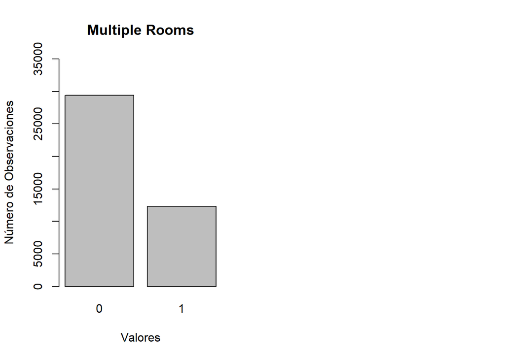

```r
par(mfrow=c(1,2))

counts <- table(D2$`Multiple Rooms`)
barplot(counts, main = "Multiple Rooms", ylab = "Número de Observaciones", xlab = "Valores" , ylim = c(0,35000))
```

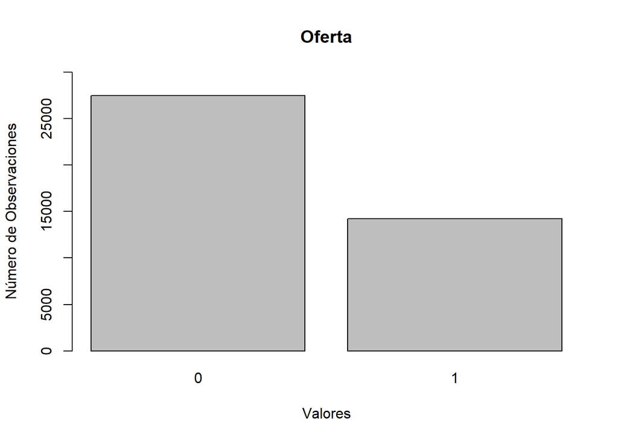

```r
counts <- table(D2$Oferta)
barplot(counts, main = "Oferta", ylab = "Número de Observaciones", xlab = "Valores" , ylim = c(0,30000))
```

Como se observa, ambas variables cuentan solamente con “0” y “1” como valores, por lo que se trata de variables booleanas. Se observa que, además de estas dos variables, se tiene que Share_Room, Private_Room y Superhost también son variables de tipo bool. Para facilitar las operaciones futuras, se procederá a cambiar los “0” y “False” a la cadena “No”, y los “1” y “True” a la cadena “Sí”.

```r
vec <- factor(D2$Oferta, labels = c('No','Sí'))
D2$Oferta <- vec
vec <- factor(D2$`Multiple Rooms`, labels = c('No','Sí'))
D2$`Multiple Rooms` <- vec
vec <- factor(D2$Share_Room, labels = c('No','Sí'))
D2$Share_Room <- vec
vec <- factor(D2$Private_Room, labels = c('No','Sí'))
D2$Private_Room <- vec
vec <- factor(D2$Superhost, labels = c('No','Sí'))
D2$Superhost <- vec
```

A continuación, se hace nuevamente un resumen para verificar los cambios realizados a las variables.

```r
summary(D2)
```

```
##     Ciudad              Precio             Day                Tipo
##  Length:41714       Min.   :   34.78   Length:41714       Length:41714
##  Class :character   1st Qu.:  144.02   Class :character   Class :character
##  Mode  :character   Median :  203.82   Mode  :character   Mode  :character
##                     Mean   :  260.09
##                     3rd Qu.:  297.37
##                     Max.   :18545.45
##  Share_Room Private_Room   Capacidad     Superhost  Multiple Rooms Oferta
##  No:41398   No:28580     Min.   :2.000   No:30055   No:29397       No:27482
##  Sí:  316   Sí:13134     1st Qu.:2.000   Sí:11659   Sí:12317       Sí:14232
##                          Median :3.000
##                          Mean   :3.237
##                          3rd Qu.:4.000
##                          Max.   :6.000
##     Limpieza       Satisfaccion    Habitaciones    Distance_Center
##  Min.   : 2.000   Min.   : 20.0   Min.   : 0.000   Min.   : 0.01504
##  1st Qu.: 9.000   1st Qu.: 90.0   1st Qu.: 1.000   1st Qu.: 1.27591
##  Median :10.000   Median : 95.0   Median : 1.000   Median : 2.25324
##  Mean   : 9.442   Mean   : 93.1   Mean   : 1.166   Mean   : 2.67979
##  3rd Qu.:10.000   3rd Qu.: 98.0   3rd Qu.: 1.000   3rd Qu.: 3.58449
##  Max.   :10.000   Max.   :100.0   Max.   :10.000   Max.   :25.28456
##  Distance_Metro      Ind.Atraccion      Ind.Restaurantes
##  Min.   : 0.002301   Min.   :  0.9263   Min.   :  0.5928
##  1st Qu.: 0.236693   1st Qu.:  5.5107   1st Qu.: 11.1320
##  Median : 0.391220   Median :  9.9511   Median : 21.8144
##  Mean   : 0.603921   Mean   : 11.7197   Mean   : 25.5536
##  3rd Qu.: 0.678702   3rd Qu.: 15.4670   3rd Qu.: 36.8214
##  Max.   :14.273577   Max.   :100.0000   Max.   :100.0000
```

#### Verificar variables númericas enteras:

A continuación se verificará que la variable Capacidad contenga solamente números enteros, ya que un airbnb no puede tener capacidad para un número no entero de personas.El mismo análisis se realizará para la variable Habitaciones, ya que sucede lo mismo con esta variable.

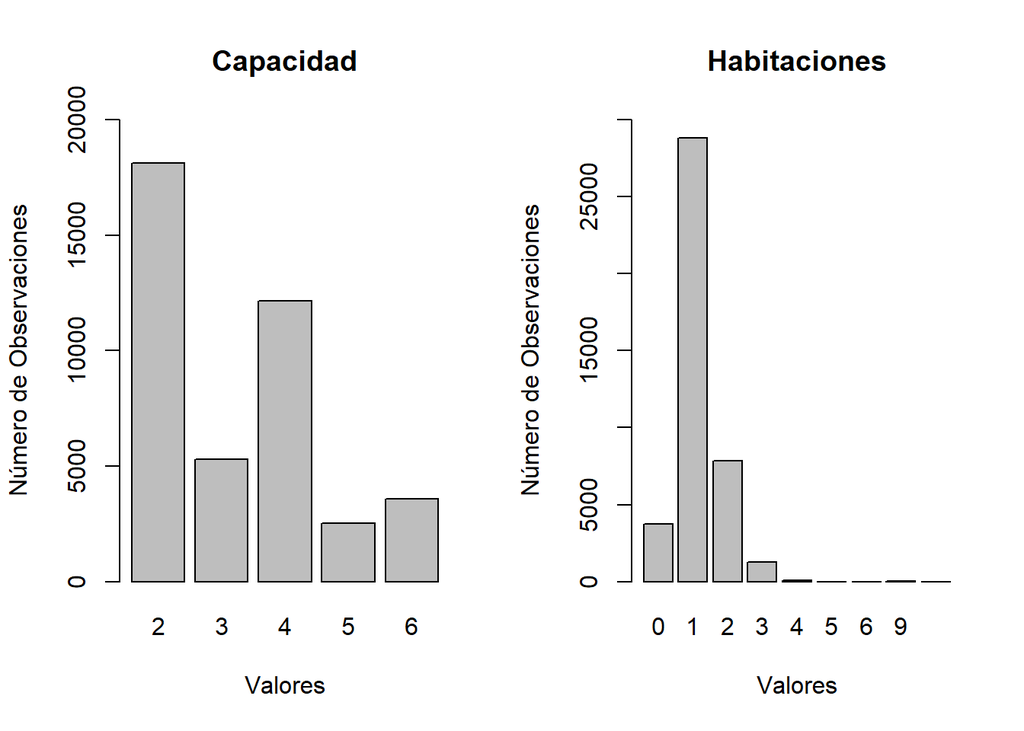

```r
par(mfrow=c(1,2))
counts <- table(D2$Capacidad)
barplot(counts, main = "Capacidad", ylab = "Número de Observaciones", xlab = "Valores" , ylim = c(0,20000))
counts <- table(D2$Habitaciones)
barplot(counts, main = "Habitaciones", ylab = "Número de Observaciones", xlab = "Valores" , ylim = c(0,30000))
```

Se observa que ambas variables cumplen con los criterios previamente mencionados. Sin embargo, se observa que la variable habitaciones tiene algunos casos con valor 0. A continuación se analizarán estos casos; para ello, se filtrarán las filas que tienen 0 habitaciones.

```r
filter(D2, Habitaciones==0)
```

| Ciudad | Precio | Day | Tipo | Share_Room | Private_Room | Capacidad | Superhost | Multiple Rooms | Oferta | Limpieza | Satisfaccion | Habitaciones | Distance_Center | Distance_Metro | Ind.Atraccion | Ind.Restaurantes |
| --- | --- | --- | --- | --- | --- | --- | --- | --- | --- | --- | --- | --- | --- | --- | --- | --- |
| Amsterdam | 310.96947 | Weekday | Entire home/apt | No | No | 2 | No | Sí | No | 9 | 94 | 0 | 4.14708669 | 0.038354694 | 6.289421 | 10.5481248 |
| Amsterdam | 350.10428 | Weekday | Private room | No | Sí | 2 | No | Sí | No | 10 | 91 | 0 | 1.09786926 | 0.956927964 | 15.517757 | 29.7241427 |
| Amsterdam | 298.78377 | Weekday | Private room | No | Sí | 2 | Sí | No | No | 9 | 94 | 0 | 4.22420859 | 1.519311044 | 5.758167 | 9.6708591 |
| Amsterdam | 344.24578 | Weekday | Entire home/apt | No | No | 2 | No | No | No | 7 | 82 | 0 | 4.15707017 | 0.101231819 | 6.293081 | 10.5552242 |
| Amsterdam | 232.23115 | Weekday | Private room | No | Sí | 2 | No | No | No | 10 | 97 | 0 | 3.71667933 | 1.556962892 | 5.488946 | 9.0371113 |
| Amsterdam | 744.49886 | Weekday | Entire home/apt | No | No | 2 | No | No | No | 10 | 92 | 0 | 2.67809200 | 1.844094478 | 11.617010 | 18.7075170 |
| Amsterdam | 1214.11665 | Weekday | Entire home/apt | No | No | 4 | No | No | No | 9 | 93 | 0 | 1.93784887 | 1.572798641 | 9.760702 | 16.9437029 |
| Amsterdam | 462.11890 | Weekday | Entire home/apt | No | No | 2 | No | No | Sí | 10 | 90 | 0 | 0.37143955 | 0.134728524 | 29.686301 | 58.8702188 |
| Amsterdam | 385.95833 | Weekday | Private room | No | Sí | 2 | No | Sí | No | 9 | 93 | 0 | 0.16133196 | 0.370092322 | 33.142181 | 71.2147178 |
| Amsterdam | 344.24578 | Weekday | Entire home/apt | No | No | 3 | No | Sí | No | 9 | 85 | 0 | 5.21296651 | 3.832716042 | 4.277054 | 7.0193817 |

[output cut: 3735 more lines]

Se observa que no hay ningún patrón o algo que indique por qué estos airbnb tienen 0 habitaciones. Como no se tiene evidencia para sustentar que un airbnb pueda tener 0 habitaciones, se procederá a colocar NA’s en las filas donde se encuentran los airbnb con 0 habitaciones.

```r
D2$Habitaciones <- replace(D2$Habitaciones, D2$Habitaciones==0, NA)
```

A continuación, se verificará que los valores de Habitaciones se hayan reemplazado correctamente.

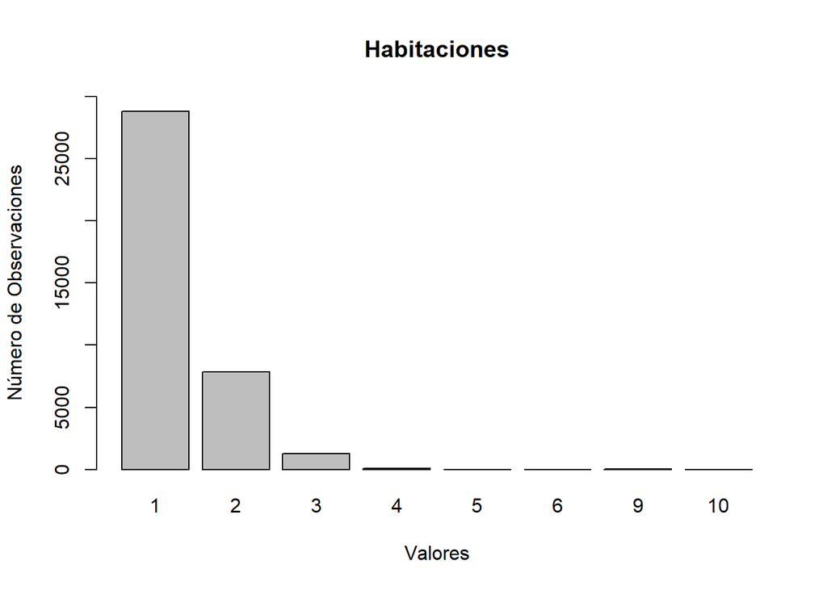

```r
counts <- table(D2$Habitaciones)
barplot(counts, main = "Habitaciones", ylab = "Número de Observaciones", xlab = "Valores" , ylim = c(0,30000))
```

Se observa que ya no existen filas con airbnb’s de 0 habitaciones.

El siguiente paso es verificar las variables Limpieza y Satisfacción. Estas variables corresponden a las puntuaciones dejadas por los usuarios de los airbnb’s. Normalmente estas puntuaciones son números enteros, para verificar que esto se cumpla, se analizarán estas variables.

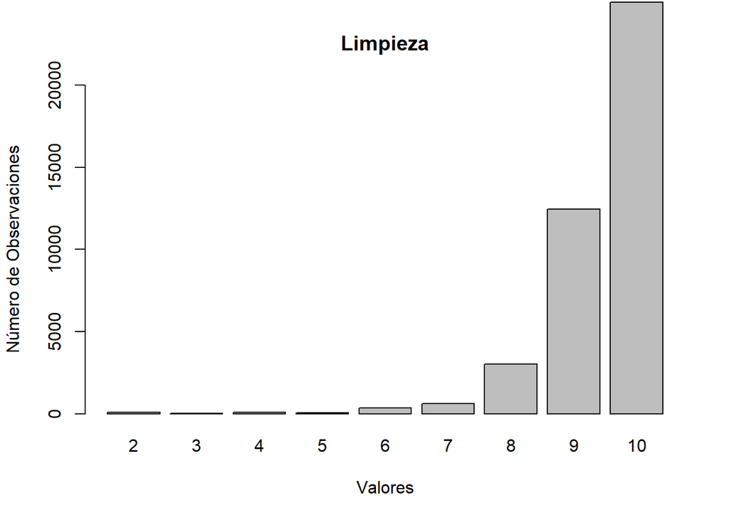

```r
counts <- table(D2$Limpieza)
barplot(counts, main = "Limpieza", ylab = "Número de Observaciones", xlab = "Valores" , ylim = c(0,20000))
```

```r
table(D2$Satisfaccion)
```

```
##
##   20   30   40   44   47   50   53   54   55   56   57   60   62   63   64   65
##   91    2   67    2   11   29   10    1    2    5    4  305    2   11    9   20
##   66   67   68   69   70   71   72   73   74   75   76   77   78   79   80   81
##    4   64   22   17  181   37   44  105   45  116  120  107  104   99 1459  131
##   82   83   84   85   86   87   88   89   90   91   92   93   94   95   96   97
##  237  400  508  564  610  964 1115 1078 2093 1510 1730 2785 2296 2809 3058 3150
##   98   99  100
## 3305 1976 8300
```

Se observa que la variable Limpieza tiene solamente números enteros en el rango 2-10 y la variable Satisfacción también, pero en el rango 20-100.

#### Verificando variables númericas no enteras

Para verificar las variables numéricas no enteras, se realizará nuevamente un resumen de las variables dentro del DataSet.

```r
summary(D2)
```

```
##     Ciudad              Precio             Day                Tipo
##  Length:41714       Min.   :   34.78   Length:41714       Length:41714
##  Class :character   1st Qu.:  144.02   Class :character   Class :character
##  Mode  :character   Median :  203.82   Mode  :character   Mode  :character
##                     Mean   :  260.09
##                     3rd Qu.:  297.37
##                     Max.   :18545.45
##
##  Share_Room Private_Room   Capacidad     Superhost  Multiple Rooms Oferta
##  No:41398   No:28580     Min.   :2.000   No:30055   No:29397       No:27482
##  Sí:  316   Sí:13134     1st Qu.:2.000   Sí:11659   Sí:12317       Sí:14232
##                          Median :3.000
##                          Mean   :3.237
##                          3rd Qu.:4.000
##                          Max.   :6.000
##
##     Limpieza       Satisfaccion    Habitaciones    Distance_Center
##  Min.   : 2.000   Min.   : 20.0   Min.   : 1.000   Min.   : 0.01504
##  1st Qu.: 9.000   1st Qu.: 90.0   1st Qu.: 1.000   1st Qu.: 1.27591
##  Median :10.000   Median : 95.0   Median : 1.000   Median : 2.25324
##  Mean   : 9.442   Mean   : 93.1   Mean   : 1.281   Mean   : 2.67979
##  3rd Qu.:10.000   3rd Qu.: 98.0   3rd Qu.: 1.000   3rd Qu.: 3.58449
##  Max.   :10.000   Max.   :100.0   Max.   :10.000   Max.   :25.28456
##                                   NA's   :3745
##  Distance_Metro      Ind.Atraccion      Ind.Restaurantes
##  Min.   : 0.002301   Min.   :  0.9263   Min.   :  0.5928
##  1st Qu.: 0.236693   1st Qu.:  5.5107   1st Qu.: 11.1320
##  Median : 0.391220   Median :  9.9511   Median : 21.8144
##  Mean   : 0.603921   Mean   : 11.7197   Mean   : 25.5536
##  3rd Qu.: 0.678702   3rd Qu.: 15.4670   3rd Qu.: 36.8214
##  Max.   :14.273577   Max.   :100.0000   Max.   :100.0000
##
```

De este resumen, se puede observar que el Indice de Atracción normalizado y el Índice de Restaurantes normalizado se encuentran dentro del rango establecido (0-100). Por otro lado, también se tienen a las variables Precio, City Center y Metro Distance. Se observa que los valores máximos se alejan considerablemente de la media. Por este motivo, se procederá a analizar cada una de estas variables.

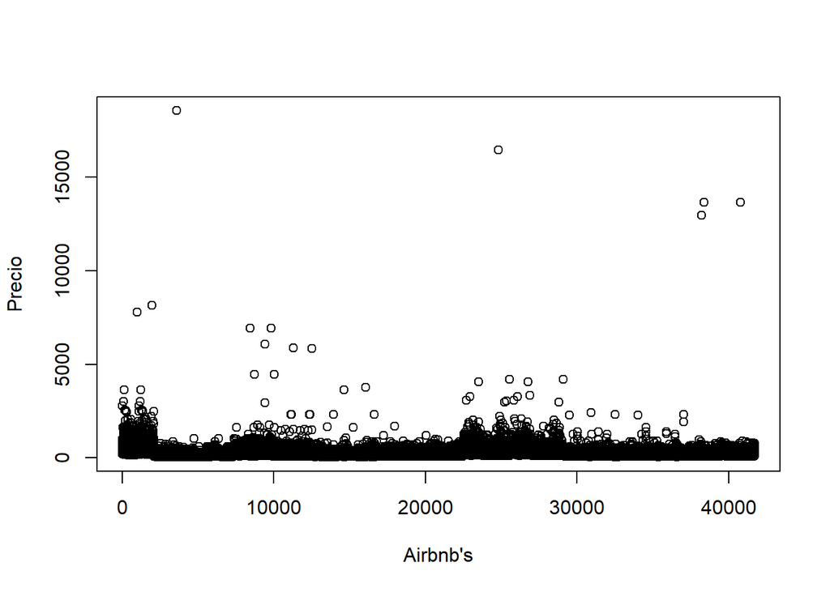

```r
plot(D2$Precio, xlab= "Airbnb's" , ylab = "Precio")
```

Se observa que hay muy pocos casos por encima de 10000 dólares, a continuación se filtrará las filas que tienen un precio mayor a 10000 USD.

```r
filter(D2, Precio>10000)
```

| Ciudad | Precio | Day | Tipo | Share_Room | Private_Room | Capacidad | Superhost | Multiple Rooms | Oferta | Limpieza | Satisfaccion | Habitaciones | Distance_Center | Distance_Metro | Ind.Atraccion | Ind.Restaurantes |
| --- | --- | --- | --- | --- | --- | --- | --- | --- | --- | --- | --- | --- | --- | --- | --- | --- |
| Athens | 18545.45 | Weekday | Entire home/apt | No | No | 2 | Sí | No | Sí | 10 | 100 | 1 | 1.196536 | 0.3811282 | 5.086455 | 20.691752 |
| Paris | 16445.61 | Weekday | Entire home/apt | No | No | 2 | No | No | No | 9 | 100 | 1 | 4.602378 | 0.1186653 | 12.700335 | 32.072497 |
| Vienna | 12942.99 | Weekday | Entire home/apt | No | No | 4 | No | No | Sí | 7 | 93 | 1 | 1.497979 | 0.3968932 | 8.864325 | 4.685995 |
| Vienna | 13664.31 | Weekday | Private room | No | Sí | 2 | No | No | No | 9 | 87 | 1 | 2.239501 | 0.4143951 | 9.191812 | 4.818080 |
| Vienna | 13656.36 | Weekend | Private room | No | Sí | 2 | No | No | No | 9 | 87 | 1 | 2.239486 | 0.4144091 | 9.191567 | 4.871302 |

Después de revisar los datos actuales en Airbnb a través de su aplicación, se encontró que, actualmente, hay 405 alojamientos en Atenas, más de 1000 en París, 168 en Vienna que tienen precios por encima de los 10000 USD. Por este motivo, estos datos se continuarán considerando dentro del dataset.

A continuación se analizará la variable Distance_Center, que representa la distancia al centro de del airbnb.

[figure not shown]

```r
plot(D2$Distance_Center, xlab= "Airbnb's" , ylab = "Distance to City Center (km)")
```

Se observa que son pocos los airbnb’s que tienen una distancia al centro por encima de 15 Km, se procederá a filtrar las filas según esta condición.

```r
filter(D2, Distance_Center>15)
```

| Ciudad | Precio | Day | Tipo | Share_Room | Private_Room | Capacidad | Superhost | Multiple Rooms | Oferta | Limpieza | Satisfaccion | Habitaciones | Distance_Center | Distance_Metro | Ind.Atraccion | Ind.Restaurantes |
| --- | --- | --- | --- | --- | --- | --- | --- | --- | --- | --- | --- | --- | --- | --- | --- | --- |
| Berlin | 797.65355 | Weekday | Entire home/apt | No | No | 6 | No | No | No | 10 | 100 | 2 | 16.45967 | 4.3271867 | 4.4455363 | 8.178475 |
| Berlin | 237.68346 | Weekday | Entire home/apt | No | No | 4 | Sí | No | No | 10 | 96 | 1 | 16.89553 | 7.9074290 | 3.3306772 | 5.966917 |
| Berlin | 127.60587 | Weekday | Private room | No | Sí | 2 | No | Sí | No | 10 | 100 | 1 | 16.05393 | 7.1732597 | 3.4930985 | 6.410745 |
| Berlin | 175.04908 | Weekday | Entire home/apt | No | No | 6 | No | No | No | 9 | 93 | 3 | 15.01625 | 5.9851928 | 3.7039014 | 6.524932 |
| Berlin | 102.13144 | Weekday | Private room | No | Sí | 3 | Sí | No | No | 10 | 100 | 1 | 15.36552 | 1.8143059 | 3.5186505 | 6.071794 |
| Berlin | 161.02646 | Weekday | Entire home/apt | No | No | 5 | No | No | No | 10 | 96 | 1 | 15.84736 | 2.0436355 | 3.4209838 | 5.902238 |
| Berlin | 295.64364 | Weekday | Entire home/apt | No | No | 2 | No | No | No | 10 | 90 | NA | 15.42294 | 6.2642725 | 3.7064945 | 6.591673 |
| Berlin | 84.60316 | Weekday | Private room | No | Sí | 2 | No | No | No | 10 | 100 | 1 | 15.96027 | 7.5553524 | 3.5331310 | 6.428173 |
| Berlin | 186.50089 | Weekday | Entire home/apt | No | No | 2 | Sí | No | No | 10 | 98 | 1 | 16.42928 | 7.7584956 | 3.4298138 | 6.733922 |
| Berlin | 115.92035 | Weekday | Private room | No | Sí | 2 | Sí | No | No | 10 | 96 | 1 | 15.49770 | 2.5813919 | 3.8279353 | 6.716629 |

[output cut: 74 more lines]

A continuación se analizarán en qué ciudades se encuentran estos airbnb’s.

```r
unique(filter(D2, Distance_Center>15)[,'Ciudad'])
```

| Ciudad |
| --- |
| Berlin |
| Budapest |

Se observa que estos airbnb’s se ubican en Berlin o Budapest. El área de estas ciudades es de 891.2 km<sup>2</sup> y 525.2 km<sup>2</sup>, respectivamente. Debido a esto, es posible que existan airbnb’s que se encuentren a 15 km o más de distancia del centro.

A continuación se analizará la variable Distance_Metro, que representa la distancia a la estación de metro más cercana al airbnb.

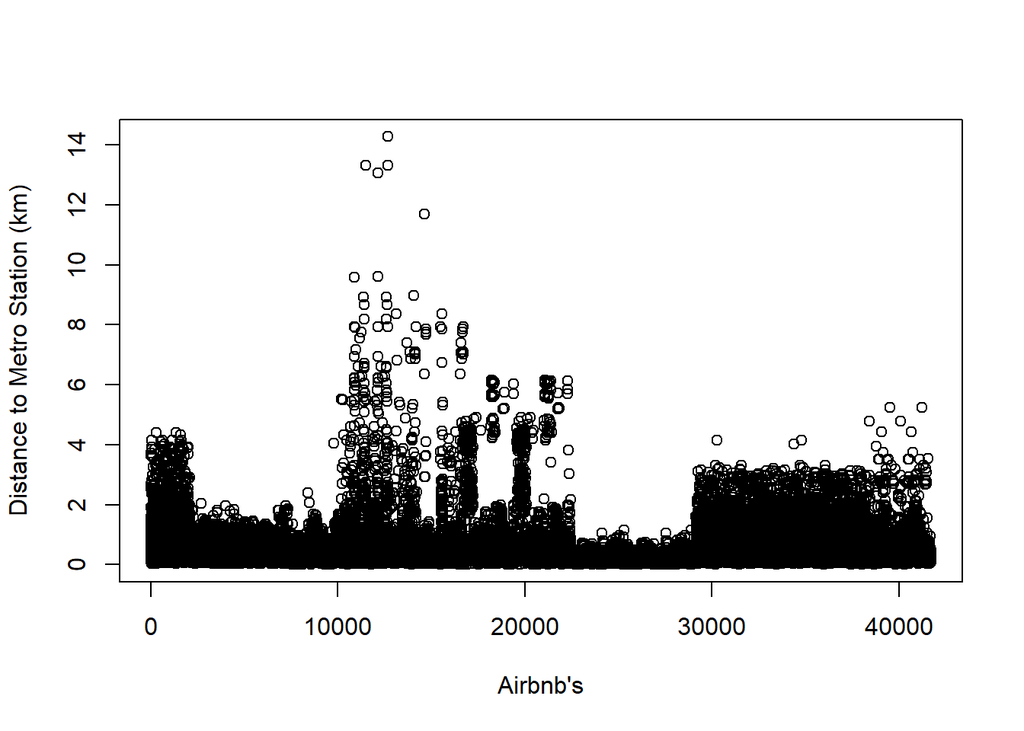

```r
plot(D2$Distance_Metro, xlab= "Airbnb's" , ylab = "Distance to Metro Station (km)")
```

Se filtrarán los airbnb’s con distancia mayor a 8km, ya que se observa que no son muchos en la gráfica.

```r
filter(D2, Distance_Metro>8)
```

| Ciudad | Precio | Day | Tipo | Share_Room | Private_Room | Capacidad | Superhost | Multiple Rooms | Oferta | Limpieza | Satisfaccion | Habitaciones | Distance_Center | Distance_Metro | Ind.Atraccion | Ind.Restaurantes |
| --- | --- | --- | --- | --- | --- | --- | --- | --- | --- | --- | --- | --- | --- | --- | --- | --- |
| Berlin | 201.69206 | Weekday | Entire home/apt | No | No | 4 | No | Sí | No | 9 | 91 | 2 | 13.47569 | 9.573733 | 3.9690569 | 6.812958 |
| Berlin | 351.50042 | Weekday | Entire home/apt | No | No | 2 | No | Sí | No | 9 | 94 | 1 | 21.29517 | 8.918050 | 3.2979676 | 5.872942 |
| Berlin | 160.09161 | Weekday | Entire home/apt | No | No | 3 | Sí | No | No | 10 | 100 | NA | 20.49568 | 8.187105 | 3.4469240 | 6.127056 |
| Berlin | 201.69206 | Weekday | Entire home/apt | No | No | 3 | No | No | No | 10 | 92 | 1 | 20.89510 | 8.670642 | 3.3773758 | 6.004530 |
| Berlin | 155.41741 | Weekday | Entire home/apt | No | No | 3 | No | No | No | 9 | 86 | 1 | 22.61745 | 13.314108 | 2.5311107 | 4.424040 |
| Berlin | 201.69206 | Weekend | Entire home/apt | No | No | 4 | No | Sí | No | 9 | 88 | 2 | 13.54350 | 9.598773 | 3.9538660 | 6.999757 |
| Berlin | 227.16650 | Weekend | Entire home/apt | No | No | 2 | No | No | No | 10 | 99 | 1 | 22.59512 | 13.069963 | 2.5274344 | 4.548095 |
| Berlin | 616.76171 | Weekend | Entire home/apt | No | No | 2 | No | Sí | No | 9 | 94 | 1 | 21.29515 | 8.918036 | 3.2969078 | 6.026086 |
| Berlin | 160.09161 | Weekend | Entire home/apt | No | No | 3 | Sí | No | No | 10 | 100 | NA | 20.49566 | 8.187084 | 3.4458158 | 6.286825 |
| Berlin | 201.69206 | Weekend | Entire home/apt | No | No | 3 | No | No | No | 10 | 92 | 1 | 20.89509 | 8.670639 | 3.3762875 | 6.161100 |

[output cut: 6 more lines]

A continuación se analizarán en qué ciudades se encuentran estos airbnb’s.

```r
unique(filter(D2, Distance_Metro>8)[,'Ciudad'])
```

| Ciudad |
| --- |
| Berlin |
| Budapest |

Nuevamente, se observa que las ciudades son Berlín y Budapest, que son ciudades bastante grandes como se mencionó en el punto anterior. Por este motivo, se considerarán como datos válidos.

#### Verificando variables de tipo char

Por último se procederá a analizar las variables Ciudad, Día y Tipo; estas son catalogadas por R como variables de tipo char. Para el caso, de la variable Ciudad, deberían haber 9 valores distintos, que representen las 9 ciudades a las que pertenece la data.

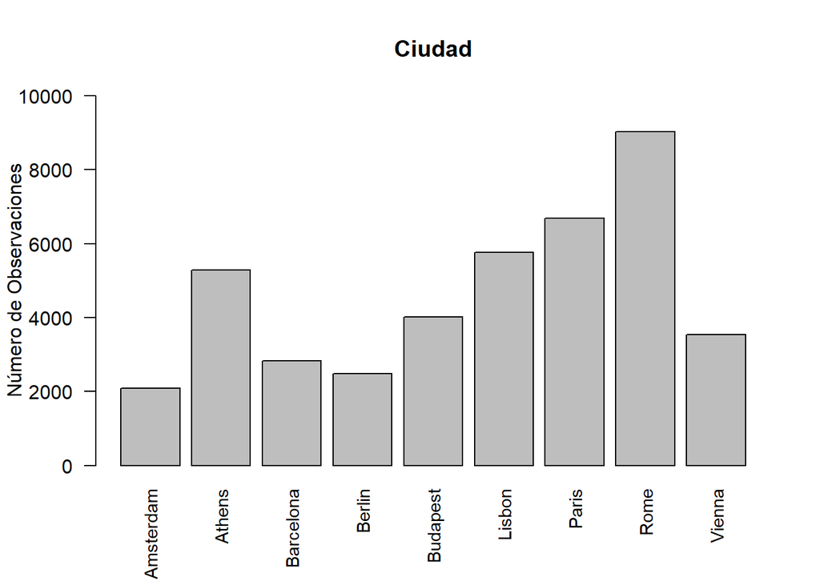

```r
counts <- table(D2$Ciudad)
barplot(counts, main = "Ciudad", ylab = "Número de Observaciones" , las=2, ylim = c(0,10000), cex.names = 0.9)
```

Una vez comprobado que solamente existen 9 ciudades en el Dataframe, se procede a revisar el Día y Tipo de airbnb.

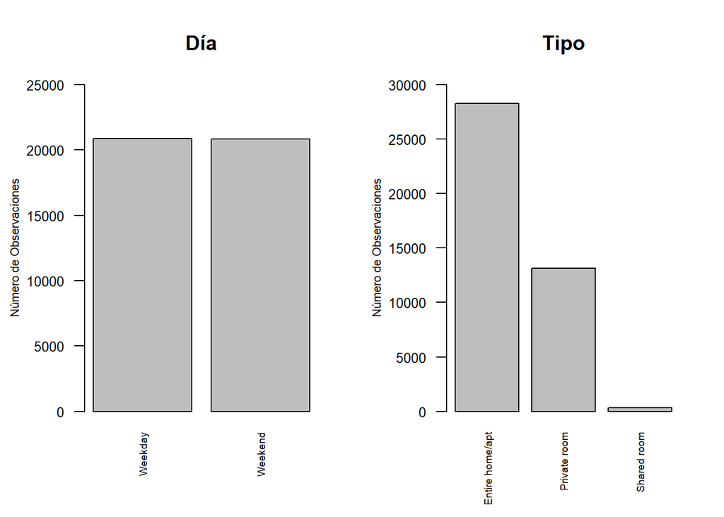

```r
par(mfrow=c(1,2)) #QUE HACE mfrow ?
counts <- table(D2$Day)
barplot(counts, main = "Día", ylab = "Número de Observaciones", las = 2, ylim = c(0,25000), cex.axis = 0.8, cex.lab = 0.7, cex.names = 0.6)
counts <- table(D2$Tipo)
barplot(counts, main = "Tipo", ylab = "Número de Observaciones", las = 2, ylim = c(0,30000), cex.axis = 0.8, cex.names = 0.6, cex.lab = 0.7)
```

Se observa que tampoco existen anomalías en estas variables, por lo que podemos concluir que nuestra data se encuentra en condiciones de ser utilizada para los análisis posteriores.

```r
library(funModeling)
status(D2)
```

|  | variable | q_zeros | p_zeros | q_na | p_na | q_inf | p_inf | type | unique |
| --- | --- | --- | --- | --- | --- | --- | --- | --- | --- |
| Ciudad | Ciudad | 0 | 0 | 0 | 0.00000000 | 0 | 0 | character | 9 |
| Precio | Precio | 0 | 0 | 0 | 0.00000000 | 0 | 0 | numeric | 8087 |
| Day | Day | 0 | 0 | 0 | 0.00000000 | 0 | 0 | character | 2 |
| Tipo | Tipo | 0 | 0 | 0 | 0.00000000 | 0 | 0 | character | 3 |
| Share_Room | Share_Room | 0 | 0 | 0 | 0.00000000 | 0 | 0 | factor | 2 |
| Private_Room | Private_Room | 0 | 0 | 0 | 0.00000000 | 0 | 0 | factor | 2 |
| Capacidad | Capacidad | 0 | 0 | 0 | 0.00000000 | 0 | 0 | numeric | 5 |
| Superhost | Superhost | 0 | 0 | 0 | 0.00000000 | 0 | 0 | factor | 2 |
| Multiple Rooms | Multiple Rooms | 0 | 0 | 0 | 0.00000000 | 0 | 0 | factor | 2 |
| Oferta | Oferta | 0 | 0 | 0 | 0.00000000 | 0 | 0 | factor | 2 |

[output cut: 7 more lines]

```r
 A <- df_status(D2,print_results=F)
```